# Trash image recognition experiments

Exploring VGG16 convolutional base

Emil Westin

12 januari 2021

## Available trash datasets

- [Trashnet](https://github.com/garythung/trashnet)
- [Trash Annotations in Context](http://tacodataset.org/) : currently 1500 images with 4784 annotations

## Data

I have downloaded from [Trashnet](https://github.com/garythung/trashnet) containing 2527 images of six classes: glass, paper, cardboard, plastic, metal, and trash.

- 501 glass
- 594 paper
- 403 cardboard
- 482 plastic
- 410 metal
- 137 trash

### Libraries used

```r
#tensorflow::install_tensorflow(extra_packages='pillow')
library(keras)
library(tensorflow)
library(tidyverse)
```

### Importing data:

```r
getwd()
```

```
[1] "C:/Users/emiwes/Desktop"
```

```r
setwd(dir = "C:/Users/emiwes/Desktop")
base_dir <- "C:/Users/emiwes/Downloads/dataset-resized/dataset-resized"
fnames <- list.files(base_dir, full.names = TRUE,recursive = T,include.dirs = F)
n <- fnames %>% length()
```

### Image preprocessing in keras

The images are stored as tensors of shape (samples, height, width, color_depth). In this case (n, 150, 150, 3), i.e. 3 colors.

Consider the following example:

```r
# load the first file name (cardboard1.jpg) with size 150x150 pixels
tt <- image_load(fnames[1], target_size = c(150, 150) )
```

```
2021-01-12 10:34:37.748134: W tensorflow/stream_executor/platform/default/dso_loader.cc:55] Could not load dynamic library 'cudart64_101.dll'; dlerror: cudart64_101.dll not found
2021-01-12 10:34:37.748271: I tensorflow/stream_executor/cuda/cudart_stub.cc:29] Ignore above cudart dlerror if you do not have a GPU set up on your machine.
```

```r
tt
```

```
<PIL.Image.Image image mode=RGB size=150x150 at 0x2BAC3896240>
```

We can convert it to array as follows:

```r
tt2 <- image_to_array(tt)
# 150 x 150 x 3
dim(tt2)
```

```
[1] 150 150   3
```

```r
# shows 3 color values for pixel (1,1):
tt2[1,1,]
```

```
[1] 242 202 167
```

Neural networks prefer to deal with small input numbers. As such, it is typical to rescale the pixel values to a [0,1] interval by dividing the pixels by 255. The array_reshape function does this and says to have the same dimension as before (150, 150, 3):

```r
tt3 <- array_reshape(tt2/255, c(150, 150, 3))
dim(tt3)
```

```
[1] 150 150   3
```

```r
tt3[1,1,]
```

```
[1] 0.9490196 0.7921569 0.6549020
```

In general, we can do this procedure for a large number of pictures.

```r
data <- array(0, c(n,150,150,3))
for(i in 1:n){
    img_path <- fnames[[i]]
    # Convert it to an array with shape (150, 150, 3)
    img <- image_load(img_path, target_size = c(150, 150))
    img_array <- image_to_array(img)
    data[i,,,] <- array_reshape(img_array/255, c(150, 150, 3))
}
# it is a good idea to save this since it can take some time to run:
# save(data, file="img_arr.RData")
```

After running the code above and saving, the data can be re-loaded as:

```r
# LOADS THE DATA FILE WITH ThE IMAGE ARRAYS
load(file = "C:/Users/emiwes/Desktop/img_arr.RData")
```

We can plot any image from the tensor like this:

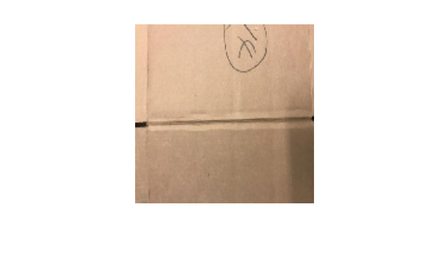

```r
plot(as.raster(data[1,,,]))
```

## Split data into train/test/validation

```r
#labs <- gsub("(.*)/([a-z0-9]+.jpg)", "\\2", fnames) # only filename
labs <- gsub(".*/([a-z]+/[a-z0-9]+.jpg)", "\\1", fnames) # including directory
labs <- as_tibble(labs)
labs %>% head() # this contains the names of the files
```

| value |
| --- |
| cardboard/cardboard1.jpg |
| cardboard/cardboard10.jpg |
| cardboard/cardboard100.jpg |
| cardboard/cardboard101.jpg |
| cardboard/cardboard102.jpg |
| cardboard/cardboard103.jpg |

```r
class_name <-  gsub("(.*)/([a-z]+)([0-9]+).jpg", "\\2", fnames)

labs$class_name <- class_name
labs$class_name <- factor(labs$class_name)

binarized <- model.matrix( value ~ 0 + ., data = labs, contrasts.arg = list(contrasts=F) )
```

```
variable 'contrasts' is absent, its contrast will be ignored
```

```r
labs <- cbind(id=labs$value, as_tibble(binarized))

colnames(labs) <- gsub("class_name","", colnames(labs) )
labs %>% head(5)
```

|  | id | cardboard | glass | metal | paper | plastic | trash |
| --- | --- | --- | --- | --- | --- | --- | --- |
| 1 | cardboard/cardboard1.jpg | 1 | 0 | 0 | 0 | 0 | 0 |
| 2 | cardboard/cardboard10.jpg | 1 | 0 | 0 | 0 | 0 | 0 |
| 3 | cardboard/cardboard100.jpg | 1 | 0 | 0 | 0 | 0 | 0 |
| 4 | cardboard/cardboard101.jpg | 1 | 0 | 0 | 0 | 0 | 0 |
| 5 | cardboard/cardboard102.jpg | 1 | 0 | 0 | 0 | 0 | 0 |

Lets say we split the data into 60% training and 40% testing.

```r
train.validation.labels %>% length()
```

```
[1] 1516
```

## Import images with flow_images

[output not shown]

[output cut: 495 more lines]

[output not shown]

[output cut: 990 more lines]

```r
train_generator <- flow_images_from_data(
  x=array_reshape(training[,,,],c(1600,150,150,3)),
  y=training.labels,
  generator = datagen,
  batch_size = 30,
  shuffle=F
)

###preparing validation data(validation data shouldn't be augmented)
validation_generator <- flow_images_from_data(
  x=array_reshape(validation[,,,],c(400,150,150,3)),
  y=validation.labels,
  batch_size = 30
)
```

```r
base_dir
```

```
[1] "C:/Users/emiwes/Downloads/dataset-resized/dataset-resized"
```

```r
k <- c(3,3)
model <- keras_model_sequential() %>%
  layer_conv_2d(filters = 32, kernel_size = k, activation = "relu", input_shape = c(150,150,3) ) %>%
  layer_max_pooling_2d(pool_size = c(2,2)) %>%
  layer_conv_2d(filters = 64, kernel_size = k, activation = "relu") %>%
  layer_max_pooling_2d(pool_size = c(2,2)) %>%
  layer_conv_2d(filters = 128, kernel_size = k, activation = "relu") %>%
  layer_max_pooling_2d(pool_size = c(2,2)) %>%
  layer_conv_2d(filters = 24, kernel_size = k, activation = "relu") %>%
  layer_max_pooling_2d(pool_size = c(2,2)) %>%
  layer_flatten() %>%
  #layer_dense(units = 512, activation = "relu") %>%
  layer_dense(units = 24, activation = "softmax")
```

```r
summary(model)
```

```
Model: "sequential_5"
_____________________________________________________________________________________________________________________
Layer (type)                                        Output Shape                                   Param #
=====================================================================================================================
conv2d_23 (Conv2D)                                  (None, 148, 148, 32)                           896
_____________________________________________________________________________________________________________________
max_pooling2d_23 (MaxPooling2D)                     (None, 74, 74, 32)                             0
_____________________________________________________________________________________________________________________
conv2d_22 (Conv2D)                                  (None, 72, 72, 64)                             18496
_____________________________________________________________________________________________________________________
max_pooling2d_22 (MaxPooling2D)                     (None, 36, 36, 64)                             0
_____________________________________________________________________________________________________________________
conv2d_21 (Conv2D)                                  (None, 34, 34, 128)                            73856
_____________________________________________________________________________________________________________________
max_pooling2d_21 (MaxPooling2D)                     (None, 17, 17, 128)                            0
_____________________________________________________________________________________________________________________
conv2d_20 (Conv2D)                                  (None, 15, 15, 24)                             27672
_____________________________________________________________________________________________________________________
max_pooling2d_20 (MaxPooling2D)                     (None, 7, 7, 24)                               0
_____________________________________________________________________________________________________________________
flatten_5 (Flatten)                                 (None, 1176)                                   0
_____________________________________________________________________________________________________________________
dense_7 (Dense)                                     (None, 24)                                     28248
=====================================================================================================================
Total params: 149,168
Trainable params: 149,168
Non-trainable params: 0
_____________________________________________________________________________________________________________________
```

Compilation step:

```r
#?compile
model %>%
  compile(
    loss = 'categorical_crossentropy',
    optimizer = optimizer_rmsprop(lr = 1e-4),
    metrics = c('accuracy')
  )
```

Fitting the model:

```r
# https://www.javaer101.com/en/article/24494572.html
history <- model %>%
  fit_generator(  train_generator,
                  steps_per_epoch = 10,
                  epochs = 6,
                  validation_data = validation_generator,
                  validation_steps = 10 )
```

[output not shown]

```r
conv_base <- application_vgg16(
  weights = "imagenet",
  include_top = FALSE,
  input_shape = c(150, 150, 3)
)
freeze_weights(conv_base)
```

```r
model.baseline %>%
 fit_generator(  train_generator,

                  steps_per_epoch = 10,
                  epochs = 10,
                  validation_data = validation_generator,
                  validation_steps = 10 )
```

[output not shown]